# Teoría de la información - Profr. Julio César Ramírez Pacheco

Entropía diferencial

Vanessa Martínez Romero, Moisés Emiliano Arellano Ávila y Fernando Gómez Perera

19/10/2020

# Entropía diferencial

La entropía de Shannon como se mencionó en los artículos que se revisaron al inicio del curso se define como el valor esperado de $-\log(p_X(k))$, al cual se le llama sorpresa. Por lo tanto la entropía de Shannon para la variable aleatoria $X$ queda especificado por la siguiente fórmula:

$$H(X) = - \sum_{k}{p_X(k)\log(p_X(k))}.$$

Nótese que esta fórmula está definida para distribuciones discretas y por lo tanto para el caso de las variables aleatorias continuas se tiene que utilizar otra definición. Shannon, extendió la entropía definida arriba mediante una simple extensión de sumatoria a integral y obtuvo lo que se llama entropía diferencial de $X$, la cual está dada por:

$$h(X) = -\int_{-\infty}^{+\infty}{f(x) \log(f(x)) \, dx}.$$

Esta entropía, en principio, se utilizó para el cálculo de la entropía para distribuciones continuas aunque ahora existen alternativas más precisas para el cálculo de la entropía de distribuciones continuas.

# Entropía diferencia de distribución uniforme

Basándonos en lo anterior, calcularemos la entropía diferencial para algunas distribuciones conocidas y verificaremos el efecto que tienen ciertos parámetros en la entropía diferencial. Recordemos que la distribución uniforme tiene la siguiente fórmula:

$$f(x) = \begin{cases}
\frac{1}{b-a} & a < x < b\\
0 & \mbox{en otro caso}
\end{cases}$$

El gráfico que define a la distribución uniforme $\mathcal{U}(2,4)$ es, por ejemplo, el siguiente:

```r
t <- seq(1, 5, length = 200)
original <- ifelse(t >= 2 & t <= 4, 1, 0)
highchart() %>% hc_add_series(cbind(t, original), name = "Densidad uniforme") %>%
    hc_add_theme(hc_theme_smpl()) %>% hc_title(text = "f(x) = 1/(b-a)") %>% hc_subtitle(text = "IT0322 - Teoría de la información") %>%
    hc_xAxis(title = list(text = "Tiempo")) %>% hc_yAxis(title = list(text = "Valores de f(x)"))
```

[interactive chart not shown]

La entropía diferencial de $\mathcal{U}(a,b)$ es por lo tanto:

$$\begin{aligned}
h(X) = & -\int_{a}^b{\left(\frac{1}{b-a}\right) \log(\frac{1}{b-a}) \, dx}\\
= & \frac{\log(b-a)}{b-a}\int_a^b{dx}\\
= & \frac{\log(b-a)}{b-a}\times (b-a)\\
h(X) = & \log(b-a)
\end{aligned}$$

Es decir, la entropía diferencial de la distribución uniforme es:

$$h(X) = \log(b-a)$$
Ahora sabemos que la varianza de la distribución uniforme es:

$$Var(X) = \frac{(b-a)^2}{12}$$

entonces, podemos relacionar la varianza de la distribución con la entropía. Supongamos que $a=0$ y $b$ es variables, entonces, el gráfico de la varianza y la entropía son:

```r
b <- seq(1, 6, length = 100)
a <- 0
varX <- (b - a)^2/12
hX <- log(b - a)
highchart() %>% hc_add_series(cbind(b, hX), name = "Entropía diferencial") %>% hc_add_series(cbind(b,
    varX), name = "Varianza") %>% hc_add_theme(hc_theme_smpl()) %>% hc_title(text = "Entropía y varianza de f(x) = 1/(b-a)") %>%
    hc_subtitle(text = "IT0322 - Teoría de la información") %>% hc_xAxis(title = list(text = "Tiempo")) %>%
    hc_yAxis(title = list(text = "Valores"))
```

[interactive chart not shown]

De lo anterior se puede concluir que la entropía incrementa con la varianza de la distribución uniforme, es decir mientras $b-a$ incremente también lo hará la entropía.

## Ejercicios

1. Suponga ahora que la varianza es constante pero la distribución se traslada sobre diversos puntos de $x$. ¿Cómo es el comportamiento de la entropía en este caso?. Sugerencia: grafique la traslación contra entropía para obtener la respuesta.

**Respuesta:**

Para que la varianza sea constante, la diferencia entre $a$ y $b$ debe mantenerse constante. Para ello, se define $a$ con valores de -5 a 5, y $b$ como $b = a + 2$.

La traslación $x$ se define como $x = \frac{a + b}{2}$, que es el punto intermedio entre $a$ y $b$.

```r
a <- seq(-5, 5, length = 100)
b <- a + 2
x <- (a + b)/2
varX <- (b - a)^2/12
hX <- log(b - a)
highchart() %>% hc_add_series(cbind(x, hX), name = "Entropía diferencial") %>% hc_add_series(cbind(x,
    varX), name = "Varianza") %>% hc_add_theme(hc_theme_smpl()) %>% hc_title(text = "Ejercicio 1: Entropía con varianza constante") %>%
    hc_subtitle(text = "IT0322 - Teoría de la información") %>% hc_xAxis(title = list(text = "Traslación")) %>%
    hc_yAxis(title = list(text = "Valores"))
```

[interactive chart not shown]

Si la varianza se mantiene constante, entonces la entropía también se mantiene constante.

2. Suponga que la densidad de una variable aleatoria $X$ está dada por:
   $$f(x) = \begin{cases}\frac{7}{4}-\frac{3}{2}x & 0< x <1\\ 0 & \mbox{otro caso}\end{cases}$$
   Hallar $h(X)$.

**Respuesta:**

La entropía para la densidad de esta variable aleatoria se obtiene por medio de la siguiente integral:

$$h(X) = -\int_0^1{\left(\frac{7}{4} - \frac{3}{2}x\right)log\left(\frac{7}{4} - \frac{3}{2}x\right)dx}$$

```r
fx <- function(x) 7/4 - 3 * x/2
hX <- integrate(function(x) -fx(x) * log(fx(x)), lower = 0, upper = 1)
hX
```

```
-0.1001556 with absolute error < 2.2e-11
```

Por lo tanto, se obtiene que

$$h(X)= -0.1002$$

# Ejercicios

1. Hallar la entropía para la siguiente función de densidad:

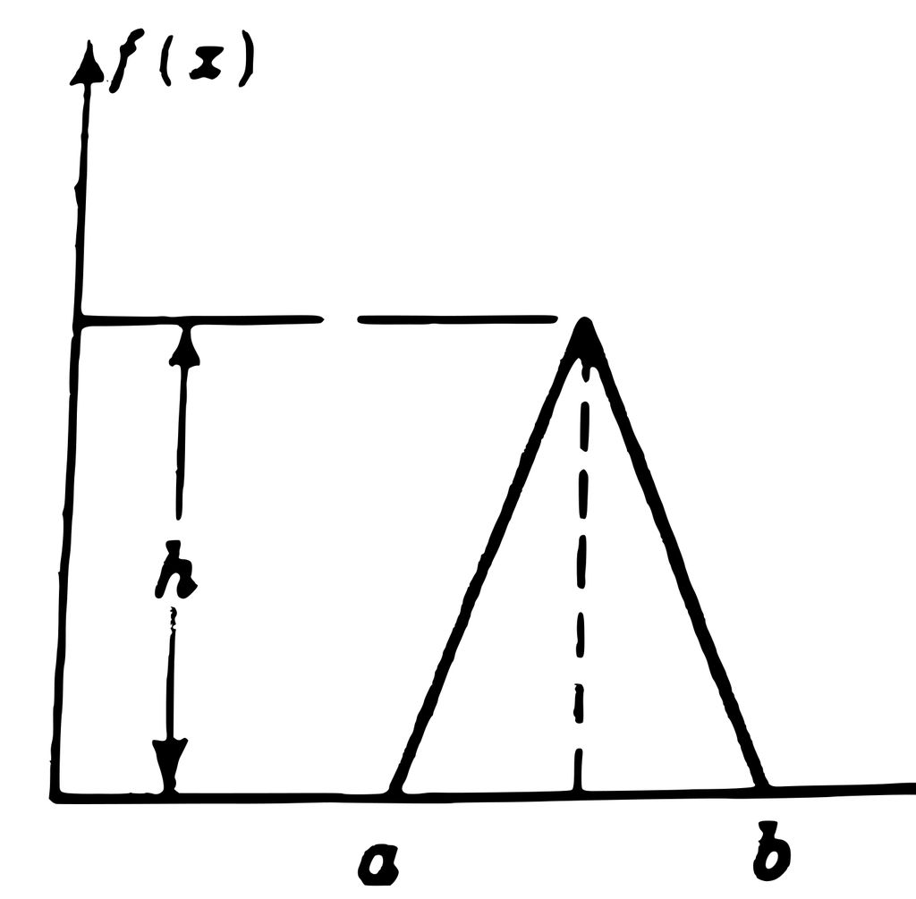

**Respuesta:**

La función de densidad es:

$$f(x) = \begin{cases}
\frac{h}{c - a} (x - a) & a \le x < c\\
h & x = c\\
\frac{h}{b - c} (b - x) & c < x \le b\\
0 & \mbox{en otro caso}
\end{cases}$$

donde

$$h = \frac{2(c - a)}{(a - c)^2 + (c - a)(b - c)}$$

y

$$c = \frac{a + b}{2}$$

Al sustituir $c$ en $h$, y simplificando este resultado, se obtiene que
$$h = \frac{2}{b-a}$$

quedando la función de densidad como

$$f(x) = \begin{cases}
\frac{2(x - a)}{(b - a)(c - a)} & a \le x < c\\
\frac{2}{b-a} & x = c\\
\frac{2(b - x)}{(b - a)(b - c)} & c < x \le b\\
0 & \mbox{en otro caso}
\end{cases}$$

que corresponde a la función de densidad de la distribución triangular.

```r
# Funciones para C
C <- function(A, B) (A + B)/2

# Funcion de densidad
fx <- function(A, B, x) {
    C <- C(A, B)
    if (A <= x & x < C) {
        return(2 * (x - A)/(B - A) * (C - A))
    } else if (x == C) {
        return(2/(B - A))
    } else if (C < x & x <= B) {
        return(2 * (B - x)/(B - A) * (B - C))
    } else {
        return(0)
    }
}
```

Para saber si el cálculo de esta función de densidad es correcto, se toma como ejemplo $a = 3$ y $b = 5$, y se calcula si $\int^{+\infty}_{-\infty}fx(x)dx = 1$.

```r
# Funcion de prueba
ex_fx <- function(x) {
    a <- 3
    b <- 5
    res <- c()
    for (i in x) {
        res <- append(res, fx(a, b, i))
    }
    return(res)
}

integrate(ex_fx, -Inf, Inf)
```

```
1 with absolute error < 2.7e-06
```

Este ejemplo genera la siguiente gráfica:

```r
t <- seq(0, 6, length = 200)
original <- ex_fx(t)
highchart() %>% hc_add_series(cbind(t, original), name = "Densidad") %>% hc_add_theme(hc_theme_smpl()) %>%
    hc_title(text = "Función de densidad con a = 3 y b = 5") %>% hc_subtitle(text = "IT0322 - Teoría de la información") %>%
    hc_xAxis(title = list(text = "Tiempo")) %>% hc_yAxis(title = list(text = "Valores de f(x)"))
```

[interactive chart not shown]

Con la función comprobada, finalmente se calcula la entropía diferencial de esta distribución:
$$h(X) = -\int_a^c{\left(\frac{2(x - a)}{(b - a)(c - a)}\right)log\left(\frac{2(x - a)}{(b - a)(c - a)}\right)}dx$$

$$- \int_c^b{\left(\frac{2(b - x)}{(b - a)(b - c)}\right)log\left(\frac{2(b - x)}{(b - a)(b - c)}\right)}dx$$

donde el resultado de ambas integrales queda como

$$h(X) = -\frac{\left(2log\left(\frac{2}{b-a}\right)-1\right)(c-a)}{2(b-a)} - \frac{\left(2log\left(\frac{2}{b-a}\right)-1\right)(b-c)}{2(b-a)}$$

que finalmente se reduce a

$$h(X) = \frac{1}{2} + log\left(\frac{b-a}{2}\right)$$

2.- Para la densidad anterior, ¿cuál es la relación entre la varianza y la entropía? ¿Existe alguna relación entre la altura $h$ y la entropía $h(X)$?

**Respuesta:**

Para obtener la varianza, primero es necesario obtener la media (que es el primer momento de la función) usando la fórmula $\mu = \int_{-\infty}^\infty{xf(x)dx}$.

$$\mu = \int_a^c{x\left(\frac{2(x - a)}{(b - a)(c - a)}\right)dx} + \int_c^bx\left(\frac{2(b - x)}{(b - a)(b- c)}\right)dx$$

donde el resultado de las integrales queda como

$$\mu = \frac{2c^3-2a^3-3ac^2+3a^3}{3(b-a)(c-a)} + \frac{b^3-3bc^2+2c^3}{3(b-a)(b-c)}$$

que finalmente se reduce a

$$\mu = \frac{a + b + c}{3}$$

Con este resultado, se puede obtener la varianza (que es el segundo momento de la función) por medio de la fórmula $\sigma^2=\int_{-\infty}^\infty{(x - \mu)^2f(x)dx}$.

$$\sigma^2 = \int_a^c{\left(x - \frac{a +b+c}{3}\right)^2\left(\frac{2(x - a)}{(b - a)(c - a)}\right)}dx$$

$$+ \int_c^b{\left(x - \frac{a +b+c}{3}\right)^2\left(\frac{2(b - x)}{(b - a)(b - c)}\right)}dx$$

donde el resultado de las integrales queda como

$$\sigma^2 = \frac{(c-a)(3c^2-2c(2b+a)+2b^2+a^2)}{18(b-a)}$$

$$- \frac{(c-b)(3c^2-2c(b+2a)+b^2+2a^2)}{18(b-a)}$$

que finalmente se reduce a

$$\sigma^2 = \frac{a^2+b^2+c^2-ab-ac-bc}{18}$$

Gráficamente la relación entre la varianza y la entropía se visualiza de la siguiente forma:

```r
b <- seq(1, 10, length = 200)
a <- 0
c <- C(a, b)
hX <- 1/2 + log((b - a)/2)
varX <- (a^2 + b^2 + c^2 - a * b - a * c - b * c)/18
highchart() %>% hc_add_series(cbind(b, hX), name = "Entropía diferencial") %>% hc_add_series(cbind(b,
    varX), name = "Varianza") %>% hc_add_theme(hc_theme_smpl()) %>% hc_title(text = "Relación entre la Varianza y la Entropía") %>%
    hc_subtitle(text = "Teoría de la información") %>% hc_xAxis(title = list(text = "Tiempo")) %>%
    hc_yAxis(title = list(text = "Valores"))
```

[interactive chart not shown]

Gráficamente la relación entre la altura $h$ y la entropía $h(X)$ se visualiza de la siguiente forma:

```r
b <- seq(1, 10, length = 200)
a <- 0
h <- 2/(b - a)
hX <- 1/2 + log((b - a)/2)
highchart() %>% hc_add_series(cbind(h, hX), name = "Entropía") %>% hc_add_theme(hc_theme_smpl()) %>%
    hc_title(text = "Entropía vs. Altura") %>% hc_subtitle(text = "Teoría de la información") %>%
    hc_xAxis(title = list(text = "Altura")) %>% hc_yAxis(title = list(text = "Entropía"))
```

[interactive chart not shown]

La altura sí modifica la entropía, y la relación entre ambas variables es que la entropía disminuye mientras la altura aumenta.